Haberman's Cancer Survival Dataset - Exploratory Data Analysis

# Structure of Dataset

Haberman’s data set contains data from the study conducted in University of Chicago’s Billings Hospital between year 1958 to 1970 for the patients who undergone surgery of breast cancer.

> There are 4 attribute in this data set out of which 3 are features and 1 class attribute as below. Also, there are 306 instances of data.
- Number of Axillary nodes(Lymph Nodes)
- Age
- Operation Year
- Survival Status

**Lymph node:** Lymph nodes are tiny, bean-shaped organs that function as lymph fluid channels filters. The lymph nodes try to catch and trap cancer cells before they reach other parts of the body as the lymph fluid leaves the breast and eventually returns to the bloodstream. Having cancer cells under your arm in the lymph nodes means an increased chance of spreading cancer.

**Age:** It represent the age of patient at which they undergone surgery (age from 30 to 83)

**Operation year:** Year in which patient was undergone surgery(1958–1969)

**Survival Status:** It represents whether patient survives after surgery for more than 5 years or less. Here if patients survived 5 years or more is represented as 1 and patients surviving less than 5 years are represented as 2.

[figure not shown]

```python
import pandas as pd
import seaborn as sns
import matplotlib.pyplot as plt
import numpy as np
```

```python
# import data
data = pd.read_csv('haberman.csv')
```

```python
print (data.shape)
```

```
(306, 4)
```

```python
#data.columns.values
print("Number of rows: " + str(data.shape[0]))
print("Number of columns: " + str(data.shape[1]))
print (data.columns)
```

```
Number of rows: 306
Number of columns: 4
Index(['age', 'year', 'nodes', 'status'], dtype='object')
```

```python
data.head()
```

|  | age | year | nodes | status |
| --- | --- | --- | --- | --- |
| 0 | 30 | 64 | 1 | 1 |
| 1 | 30 | 62 | 3 | 1 |
| 2 | 30 | 65 | 0 | 1 |
| 3 | 31 | 59 | 2 | 1 |
| 4 | 31 | 65 | 4 | 1 |

```python
data.describe()
```

|  | age | year | nodes | status |
| --- | --- | --- | --- | --- |
| count | 306.000000 | 306.000000 | 306.000000 | 306.000000 |
| mean | 52.457516 | 62.852941 | 4.026144 | 1.264706 |
| std | 10.803452 | 3.249405 | 7.189654 | 0.441899 |
| min | 30.000000 | 58.000000 | 0.000000 | 1.000000 |
| 25% | 44.000000 | 60.000000 | 0.000000 | 1.000000 |
| 50% | 52.000000 | 63.000000 | 1.000000 | 1.000000 |
| 75% | 60.750000 | 65.750000 | 4.000000 | 2.000000 |
| max | 83.000000 | 69.000000 | 52.000000 | 2.000000 |

```python
#starting with univariate analysis
data["status"].value_counts()
```

```
1    225
2     81
Name: status, dtype: int64
```

```python
data["status"].value_counts(normalize=1)
```

```
1    0.735294
2    0.264706
Name: status, dtype: float64
```

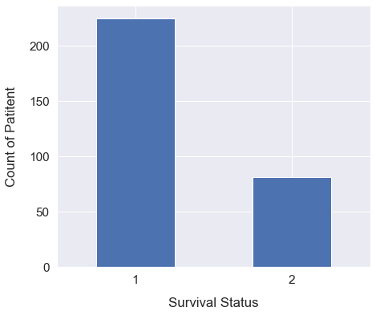

```python
sns.set(font_scale=1.4)
data['status'].value_counts().plot(kind='bar', figsize=(7, 6), rot=0);
plt.xlabel("Survival Status", labelpad=14)
plt.ylabel("Count of Patitent", labelpad=14)
plt.show();
```

## Multivariate approach

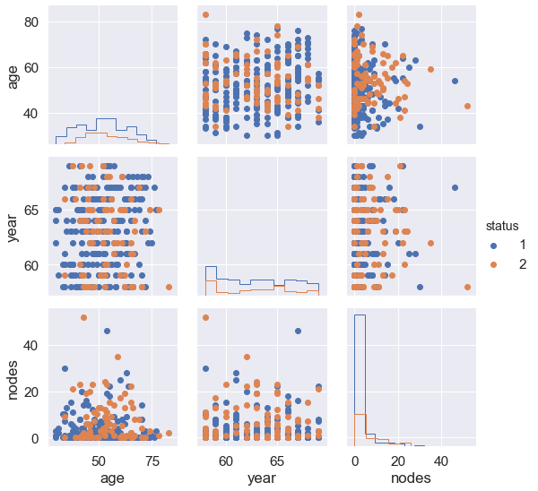

```python
x = sns.PairGrid(data, hue = "status", vars = ["age", "year", "nodes"])
x = x.map_diag(plt.hist, histtype = "step")
x = x.map_offdiag(plt.scatter)
x = x.add_legend()
```

> **Observation:** From above observation one can clearly observe that we cannot get any outcome from multivariate analysis as it is too much chaotic

# Univariate approach

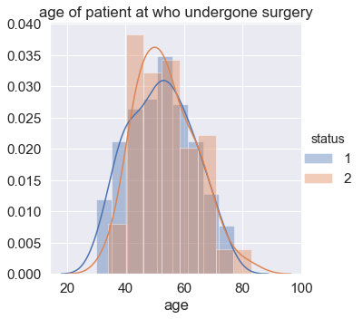

```python
sns.FacetGrid(data, hue="status", height=5).map(sns.distplot, "age").add_legend();
plt.title("age of patient at who undergone surgery")
```

> **Observation**: We can not effectively classify patients from same year groups have survived or did not survive breast surgery as We can also see survival is decreasing with time. Now we will compare above point with year

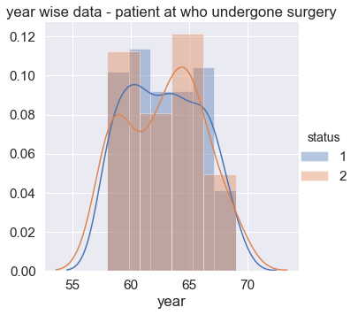

```python
sns.FacetGrid(data, hue="status", height=5).map(sns.distplot, "year").add_legend();
plt.title("year wise data - patient at who undergone surgery")
```

> **Observation:** We will be not be able to conclud something from this as we can see it is over lapped lets try it by doing PDF and CDF

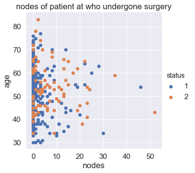

```python
sns.FacetGrid(data, hue='status', height = 5).map(plt.scatter, 'nodes', 'age').add_legend();
plt.title("nodes of patient at who undergone surgery")
```

```python
status_one = data.loc[data["status"] == 1];
status_two = data.loc[data["status"] == 2];
```

```
[0.05333333 0.10666667 0.12444444 0.09333333 0.16444444 0.16444444
 0.09333333 0.11111111 0.06222222 0.02666667]
[30.  34.7 39.4 44.1 48.8 53.5 58.2 62.9 67.6 72.3 77. ]
[0.03703704 0.12345679 0.19753086 0.19753086 0.13580247 0.12345679
 0.09876543 0.04938272 0.02469136 0.01234568]
[34.  38.9 43.8 48.7 53.6 58.5 63.4 68.3 73.2 78.1 83. ]
```

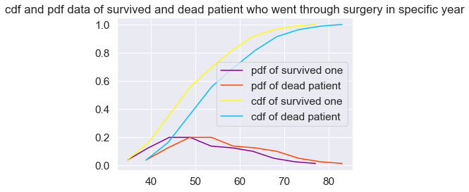

```python
counts, bin_edges = np.histogram(status_one['age'], bins=10,
                                 density = True)
pdf = counts/(sum(counts))
print(pdf);
print(bin_edges);

counts, bin_edgess = np.histogram(status_two['age'], bins=10,
                                 density = True)
pdf = counts/(sum(counts))
print(pdf);
print(bin_edgess);

cdf = np.cumsum(pdf)
plt.plot(bin_edges[1:],pdf, color = "#8B008B", label = "pdf of survived one");
plt.plot(bin_edgess[1:],pdf, color = "#FF4500", label = "pdf of dead patient");
plt.plot(bin_edges[1:], cdf, color = "#FFFF00", label = "cdf of survived one");
plt.plot(bin_edgess[1:],cdf, color = "#00BFFF", label = "cdf of dead patient");
plt.legend()
plt.title("cdf and pdf data of survived and dead patient who went through surgery in specific year")
plt.show()
```

```
[0.18666667 0.10666667 0.10222222 0.07111111 0.09777778 0.10222222
 0.06666667 0.09777778 0.09333333 0.07555556]
[58.  59.1 60.2 61.3 62.4 63.5 64.6 65.7 66.8 67.9 69. ]
[0.25925926 0.04938272 0.03703704 0.08641975 0.09876543 0.09876543
 0.16049383 0.07407407 0.04938272 0.08641975]
[58.  59.1 60.2 61.3 62.4 63.5 64.6 65.7 66.8 67.9 69. ]
```

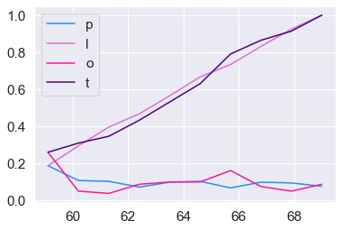

```python
counts, bin_edges = np.histogram(status_one['year'], bins=10,
                                 density = True)
pdf = counts/(sum(counts))
print(pdf);
print(bin_edges);

cdf = np.cumsum(pdf)
plt.plot(bin_edges[1:],pdf, color = "#1E90FF", label = "pdf of survived one");
plt.plot(bin_edges[1:], cdf, color = "#DA70D6", label = "cdf of survived one");

counts, bin_edgess = np.histogram(status_two['year'], bins=10,
                                 density = True)
pdf = counts/(sum(counts))
print(pdf);
print(bin_edgess);
cdf = np.cumsum(pdf)
plt.plot(bin_edgess[1:],pdf, color = "#FF1493", label = "pdf of dead patient");
plt.plot(bin_edgess[1:], cdf, color = "#4B0082", label = "cdf of dead patient");
plt.legend("plotting cdf and pdf of survived and dead patient who ")
plt.title
plt.show()
```

```
[0.83555556 0.08       0.02222222 0.02666667 0.01777778 0.00444444
 0.00888889 0.         0.         0.00444444]
[ 0.   4.6  9.2 13.8 18.4 23.  27.6 32.2 36.8 41.4 46. ]
[0.56790123 0.14814815 0.13580247 0.04938272 0.07407407 0.
 0.01234568 0.         0.         0.01234568]
[ 0.   5.2 10.4 15.6 20.8 26.  31.2 36.4 41.6 46.8 52. ]
```

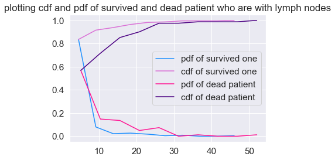

```python
counts, bin_edges = np.histogram(status_one['nodes'], bins=10,
                                 density = True)
pdf = counts/(sum(counts))
print(pdf);
print(bin_edges);

cdf = np.cumsum(pdf)
plt.plot(bin_edges[1:],pdf, color = "#1E90FF", label = "pdf of survived one");
plt.plot(bin_edges[1:], cdf, color = "#DA70D6", label = "cdf of survived one");

counts, bin_edgess = np.histogram(status_two['nodes'], bins=10,
                                 density = True)
pdf = counts/(sum(counts))
print(pdf);
print(bin_edgess);
cdf = np.cumsum(pdf)
plt.plot(bin_edgess[1:],pdf, color = "#FF1493", label = "pdf of dead patient");
plt.plot(bin_edgess[1:], cdf, color = "#4B0082", label = "cdf of dead patient");
plt.title("plotting cdf and pdf of survived and dead patient who are with lymph nodes")
plt.legend()
plt.show()
```

> **Observation:** Same as Histogram PDF and CDF plotting does not provide proper classification between survived and dead patient. Only information that could really be understood is people age between 30-35 will survive , same can be known from Histogram. But from pdf and cdf plot of nodes we can see that the Person with high number of axillary nodes have less probablity of surviving and maximum number of persons who survived have less than 3 axillary nodes. so for the classification of survival status and operation year is the least important attribute.

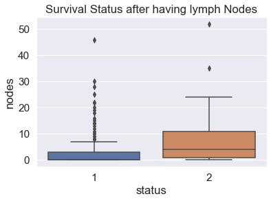

```python
sns.boxplot(x='status',y='nodes', data=data)
plt.title("Survival Status after having lymph Nodes")
```

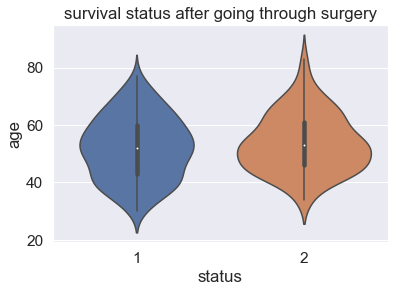

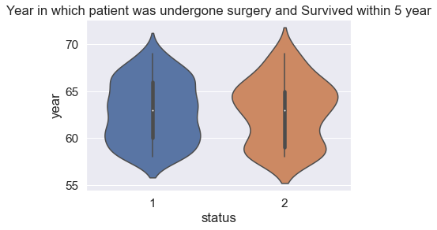

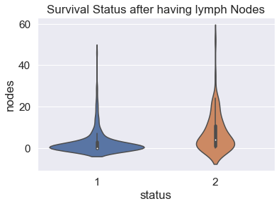

```python
#performing vilon plot by using all attributes
sns.violinplot(x = 'status', y = "age", data = data)
plt.title("survival status after going through surgery")
plt.show()
sns.violinplot(x = 'status', y = "year", data = data)
plt.title("Year in which patient was undergone surgery and Survived within 5 year")
plt.show()
sns.violinplot(x = 'status', y = "nodes", data = data)
plt.title("Survival Status after having lymph Nodes")
plt.show()
```

> **Observation:** It has been found that people live long if they have detected fewer axillary nodes and vice versa but it is still difficult to identify but this is the best data you can choose from among all. So I accept the Axillary Nodes PDF and can conclude the result below

```python
import plotly.express as px
fig = px.scatter_3d(data, x='nodes', y='year', z='age'
              ,color='status')
fig.show()
```

[interactive chart not shown]

Conclusion

> 1. Number of person who has a high number of lymph nodes indicates that they have high probablity of not surviving so lymph nodes is most important feature/attribute to predict the survival status of person.
> 2. Maximum number of patients who performed surgery were between 42-60 years of age
> 3. The majority of the surgeries were performed between 1960 - 1966.
> 4. The person with Zero lymph node is most likely to be survive.
> 5. The least usefull attribute to predict the survival status of person is 'Operation Year'